# Part II - Factors that affect the outcome of a loan

## by Charles Nikoro

## Investigation Overview

In this investigation, I wanted to explore the factors that could affect a loan's outcome. The main focus were on the principal outstanding, current number of days the borrower was delinquent, the employment status, and the term of the loan.

## Dataset Overview

The dataset comprises of approximately 114,000 records of loan applications from November 11, 2005 to March 3, 2014. Each record contains 81 features or variables.

I only considered loans that were either completed, defaulted, or charged-off. Apart from the main variable of interest, `LoanStatus`, others explored in this investigation are: `LoanOriginalAmount`, `LP_CustomerPrincipalPayments`,`BorrowerAPR`, `LP_InterestandFees`, `Term`, `LoanCurrentDaysDelinquent`, `EmploymentStatus`, `ListingCategory (numeric)`, and `TotalProsperLoans`.

`EmploymentStatus` variable comprises of "Not employed", "Full-time", "Part-time", "Retired", "Employed", "Self-employed", "Other", and "Not available" categories. For this investigation, I only considered records whose employment status are known. Therefore, records with an "Other" or "Not available" status where not considered. Furthermore, since it is safe to assume that borrowers with a "Full-time" and "Part-time" status have an employer, I merged them with those whose status is "Employed". Consequently, the categories of employment status considered are "Not employed", "Self-employed", "Employed", and "Retired".

After performing the above wrangling process, I was left with 46,688 records which was explored for this investigation. A new variable was created called `LoanPrincipalOutstanding` that contains the principal outstanding of each record.

## Distribution of Loan Status

Most of the borrowers completed their loans as we can see from the count plot.

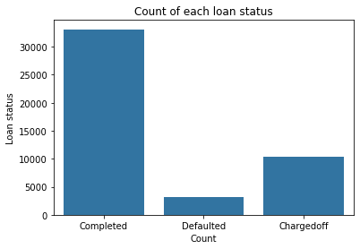

## Distribution of principal outstandings

The distribution is unimodal with most of the borrowers having no outstandings which collaborate with our observation that most of them completed their loans. The distribution is plotted with a log scale on the y-axis.

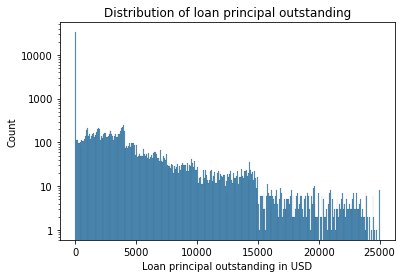

## Distribution of number of days borrowers were delinquent

The distribution is also unimodal with a peak around 0 which shows that most borrowers were not delinquent on their payments. It was also plotted with a log scale on the y-axis.

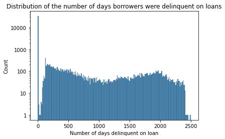

## Principal outstanding for each loan status

The box plot shows defaulted loans have a slightly larger median principal outstanding compared to charged-off loans. Completed loans have a median value of 0.

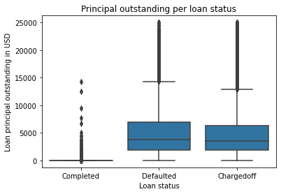

## Number of days delinquent for each loan status

There is an increase in the number of days borrowers were delinquent across the loan status with charged off loans having the highest median value as expected.

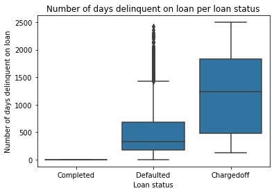

## Principal outstanding per loan status across each loan term

There are more outstandings for 5-year loan terms that were defaulted or charged off compared to the other terms. The plot suggests that as the loan term increases borrowers are more likely to default or have their loans charged off.

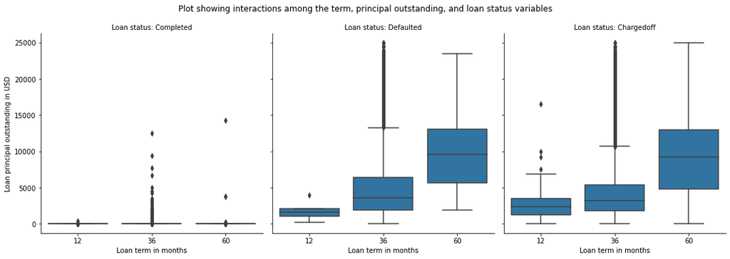

## Principal outstanding per loan status for each employment status

We can see a consistent pattern for both defaulted and charged off loans with self-employed borrowers having the highest median value of principal outstandings in both cases.

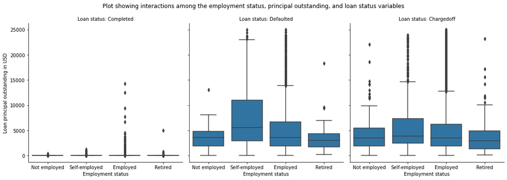

## Number of days delinquent per loan status for each employment status

We can see a consistent pattern among the employment status for each loan outcome. Notice that the number of days borrowers were delinquent generally increases with each loan status. An interesting observation is that those who are unemployed with a default or charged-off loan status have the lowest median value of the number of days borrowers were delinquent. This seems to suggest that their loans are given the defaulted or charged off status earlier than the other category of borrowers probably because it is assumed they are not able to complete their loans once they start to miss their monthly payments.

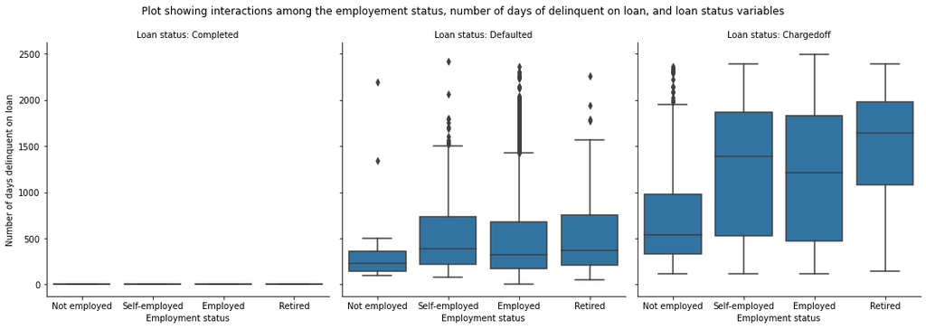